# Project: Investigating patient appointment attendance dataset

- Introduction
- Data Wrangling
- Exploratory Data Analysis
- Conclusions

## Introduction

This project investigates the no-show dataset which examines a brazillian collected 110.527 medical appointments and 14 associated variables that provides us with a helpful insight into the common characteristics of patients who tend to book an appointment and fail to show up. The dataset variables are self-explanatory, however, the only variable that requires further inspection is the 'scholarship' variable: it indicates whether or not the patient is enrolled in Brasilian welfare program Bolsa Família. The Bolsa Família is a social welfare program that aids poor family with financial support if they have children, and families must ensure school attendance of their children and recieving their vaccination Furthermore, the last variable constitue the output variable. the no_show variable outputs 'Yes' if the patient failed to show up, and 'No' if they patient showed up to the appointment.

**The common questions this project examines, revolves around the common characteristics of patients that fail to attend the appointment. The project investigates the following:**

1. Are people not commited to a scholarship more likely to not show up?
2. What age group of patients that are more likely to not show up?
3. What is the common medical issue of patients more likely to not show up?

```python
# Use this cell to set up import statements for all of the packages that you
#   plan to use.
import pandas as pd
import numpy as np
import matplotlib.pyplot as plt
% matplotlib inline

# Remember to include a 'magic word' so that your visualizations are plotted
#   inline with the notebook. See this page for more:
#   http://ipython.readthedocs.io/en/stable/interactive/magics.html
```

## Data Wrangling

### Data Overview

```python
# Load your data and print out a few lines. Perform operations to inspect data
df = pd.read_csv('noshow.csv')
df.head()
```

|  | PatientId | AppointmentID | Gender | ScheduledDay | AppointmentDay | Age | Neighbourhood | Scholarship | Hipertension | Diabetes | Alcoholism | Handcap | SMS_received | No-show |
| --- | --- | --- | --- | --- | --- | --- | --- | --- | --- | --- | --- | --- | --- | --- |
| 0 | 2.987250e+13 | 5642903 | F | 2016-04-29T18:38:08Z | 2016-04-29T00:00:00Z | 62 | JARDIM DA PENHA | 0 | 1 | 0 | 0 | 0 | 0 | No |
| 1 | 5.589978e+14 | 5642503 | M | 2016-04-29T16:08:27Z | 2016-04-29T00:00:00Z | 56 | JARDIM DA PENHA | 0 | 0 | 0 | 0 | 0 | 0 | No |
| 2 | 4.262962e+12 | 5642549 | F | 2016-04-29T16:19:04Z | 2016-04-29T00:00:00Z | 62 | MATA DA PRAIA | 0 | 0 | 0 | 0 | 0 | 0 | No |
| 3 | 8.679512e+11 | 5642828 | F | 2016-04-29T17:29:31Z | 2016-04-29T00:00:00Z | 8 | PONTAL DE CAMBURI | 0 | 0 | 0 | 0 | 0 | 0 | No |
| 4 | 8.841186e+12 | 5642494 | F | 2016-04-29T16:07:23Z | 2016-04-29T00:00:00Z | 56 | JARDIM DA PENHA | 0 | 1 | 1 | 0 | 0 | 0 | No |

```python
#types of variables
df.info()
```

```
<class 'pandas.core.frame.DataFrame'>
RangeIndex: 110527 entries, 0 to 110526
Data columns (total 14 columns):
PatientId         110527 non-null float64
AppointmentID     110527 non-null int64
Gender            110527 non-null object
ScheduledDay      110527 non-null object
AppointmentDay    110527 non-null object
Age               110527 non-null int64
Neighbourhood     110527 non-null object
Scholarship       110527 non-null int64
Hipertension      110527 non-null int64
Diabetes          110527 non-null int64
Alcoholism        110527 non-null int64
Handcap           110527 non-null int64
SMS_received      110527 non-null int64
No-show           110527 non-null object
dtypes: float64(1), int64(8), object(5)
memory usage: 11.8+ MB
```

```python
#number of rows and columns in the dataset
df.shape
```

```
(110527, 14)
```

```python
#overview description of the dataset
df.describe()
```

|  | PatientId | AppointmentID | Age | Scholarship | Hipertension | Diabetes | Alcoholism | Handcap | SMS_received |
| --- | --- | --- | --- | --- | --- | --- | --- | --- | --- |
| count | 1.105270e+05 | 1.105270e+05 | 110527.000000 | 110527.000000 | 110527.000000 | 110527.000000 | 110527.000000 | 110527.000000 | 110527.000000 |
| mean | 1.474963e+14 | 5.675305e+06 | 37.088874 | 0.098266 | 0.197246 | 0.071865 | 0.030400 | 0.022248 | 0.321026 |
| std | 2.560949e+14 | 7.129575e+04 | 23.110205 | 0.297675 | 0.397921 | 0.258265 | 0.171686 | 0.161543 | 0.466873 |
| min | 3.921784e+04 | 5.030230e+06 | -1.000000 | 0.000000 | 0.000000 | 0.000000 | 0.000000 | 0.000000 | 0.000000 |
| 25% | 4.172614e+12 | 5.640286e+06 | 18.000000 | 0.000000 | 0.000000 | 0.000000 | 0.000000 | 0.000000 | 0.000000 |
| 50% | 3.173184e+13 | 5.680573e+06 | 37.000000 | 0.000000 | 0.000000 | 0.000000 | 0.000000 | 0.000000 | 0.000000 |
| 75% | 9.439172e+13 | 5.725524e+06 | 55.000000 | 0.000000 | 0.000000 | 0.000000 | 0.000000 | 0.000000 | 1.000000 |
| max | 9.999816e+14 | 5.790484e+06 | 115.000000 | 1.000000 | 1.000000 | 1.000000 | 1.000000 | 4.000000 | 1.000000 |

The above illustrates the inputs of each variable. Scholarship, Diabetes, Alcholism, SMS_recieved take 0 corresponding to false, or 1 corresponding to True. The Handicap variable takes a range of ( 0 - 4), searching further for the meaning of each number in the dataset Discussion board, i have come across the following:  
*'each time correspond to one type and the number is the sum of all conditions. 4 means a person with fisical, visual, and other handicap conditions.'*  
for simplification, we're only interested if weather the patient suffers from a handicap condition or not. This will be addressed later on the project as 0 / 1 resembling the rest of the variables.

### Data Cleaning

```python
df['Handcap'].unique()
```

```
array([0, 1, 2, 3, 4])
```

```python
#checking for null values
df.isnull().sum().sum()
```

```
0
```

```python
#checking for duplicated values #1
df.duplicated().sum()
```

```
0
```

```python
#checking for duplicated values #2
x = df.duplicated()
y =0
for i in x:
     if i == True:
        y+=1

print(y)
```

```
0
```

```python
df.columns
```

```
Index(['PatientId', 'AppointmentID', 'Gender', 'ScheduledDay',
       'AppointmentDay', 'Age', 'Neighbourhood', 'Scholarship', 'Hipertension',
       'Diabetes', 'Alcoholism', 'Handcap', 'SMS_received', 'No-show'],
      dtype='object')
```

```python
#renaming and fixing column names to lower cases
df.columns = map(str.lower, df.columns)
#fixing no-show to no_show
df.rename(columns={'no-show':'no_show'}, inplace=True )
df
```

|  | patientid | appointmentid | gender | scheduledday | appointmentday | age | neighbourhood | scholarship | hipertension | diabetes | alcoholism | handcap | sms_received | no_show |
| --- | --- | --- | --- | --- | --- | --- | --- | --- | --- | --- | --- | --- | --- | --- |
| 0 | 2.987250e+13 | 5642903 | F | 2016-04-29T18:38:08Z | 2016-04-29T00:00:00Z | 62 | JARDIM DA PENHA | 0 | 1 | 0 | 0 | 0 | 0 | No |
| 1 | 5.589978e+14 | 5642503 | M | 2016-04-29T16:08:27Z | 2016-04-29T00:00:00Z | 56 | JARDIM DA PENHA | 0 | 0 | 0 | 0 | 0 | 0 | No |
| 2 | 4.262962e+12 | 5642549 | F | 2016-04-29T16:19:04Z | 2016-04-29T00:00:00Z | 62 | MATA DA PRAIA | 0 | 0 | 0 | 0 | 0 | 0 | No |
| 3 | 8.679512e+11 | 5642828 | F | 2016-04-29T17:29:31Z | 2016-04-29T00:00:00Z | 8 | PONTAL DE CAMBURI | 0 | 0 | 0 | 0 | 0 | 0 | No |
| 4 | 8.841186e+12 | 5642494 | F | 2016-04-29T16:07:23Z | 2016-04-29T00:00:00Z | 56 | JARDIM DA PENHA | 0 | 1 | 1 | 0 | 0 | 0 | No |
| 5 | 9.598513e+13 | 5626772 | F | 2016-04-27T08:36:51Z | 2016-04-29T00:00:00Z | 76 | REPÚBLICA | 0 | 1 | 0 | 0 | 0 | 0 | No |
| 6 | 7.336882e+14 | 5630279 | F | 2016-04-27T15:05:12Z | 2016-04-29T00:00:00Z | 23 | GOIABEIRAS | 0 | 0 | 0 | 0 | 0 | 0 | Yes |
| 7 | 3.449833e+12 | 5630575 | F | 2016-04-27T15:39:58Z | 2016-04-29T00:00:00Z | 39 | GOIABEIRAS | 0 | 0 | 0 | 0 | 0 | 0 | Yes |
| 8 | 5.639473e+13 | 5638447 | F | 2016-04-29T08:02:16Z | 2016-04-29T00:00:00Z | 21 | ANDORINHAS | 0 | 0 | 0 | 0 | 0 | 0 | No |
| 9 | 7.812456e+13 | 5629123 | F | 2016-04-27T12:48:25Z | 2016-04-29T00:00:00Z | 19 | CONQUISTA | 0 | 0 | 0 | 0 | 0 | 0 | No |
| 10 | 7.345362e+14 | 5630213 | F | 2016-04-27T14:58:11Z | 2016-04-29T00:00:00Z | 30 | NOVA PALESTINA | 0 | 0 | 0 | 0 | 0 | 0 | No |
| 11 | 7.542951e+12 | 5620163 | M | 2016-04-26T08:44:12Z | 2016-04-29T00:00:00Z | 29 | NOVA PALESTINA | 0 | 0 | 0 | 0 | 0 | 1 | Yes |
| 12 | 5.666548e+14 | 5634718 | F | 2016-04-28T11:33:51Z | 2016-04-29T00:00:00Z | 22 | NOVA PALESTINA | 1 | 0 | 0 | 0 | 0 | 0 | No |
| 13 | 9.113946e+14 | 5636249 | M | 2016-04-28T14:52:07Z | 2016-04-29T00:00:00Z | 28 | NOVA PALESTINA | 0 | 0 | 0 | 0 | 0 | 0 | No |
| 14 | 9.988472e+13 | 5633951 | F | 2016-04-28T10:06:24Z | 2016-04-29T00:00:00Z | 54 | NOVA PALESTINA | 0 | 0 | 0 | 0 | 0 | 0 | No |
| 15 | 9.994839e+10 | 5620206 | F | 2016-04-26T08:47:27Z | 2016-04-29T00:00:00Z | 15 | NOVA PALESTINA | 0 | 0 | 0 | 0 | 0 | 1 | No |
| 16 | 8.457439e+13 | 5633121 | M | 2016-04-28T08:51:47Z | 2016-04-29T00:00:00Z | 50 | NOVA PALESTINA | 0 | 0 | 0 | 0 | 0 | 0 | No |
| 17 | 1.479497e+13 | 5633460 | F | 2016-04-28T09:28:57Z | 2016-04-29T00:00:00Z | 40 | CONQUISTA | 1 | 0 | 0 | 0 | 0 | 0 | Yes |
| 18 | 1.713538e+13 | 5621836 | F | 2016-04-26T10:54:18Z | 2016-04-29T00:00:00Z | 30 | NOVA PALESTINA | 1 | 0 | 0 | 0 | 0 | 1 | No |
| 19 | 7.223289e+12 | 5640433 | F | 2016-04-29T10:43:14Z | 2016-04-29T00:00:00Z | 46 | DA PENHA | 0 | 0 | 0 | 0 | 0 | 0 | No |
| 20 | 6.222575e+14 | 5626083 | F | 2016-04-27T07:51:14Z | 2016-04-29T00:00:00Z | 30 | NOVA PALESTINA | 0 | 0 | 0 | 0 | 0 | 0 | Yes |
| 21 | 1.215484e+13 | 5628338 | F | 2016-04-27T10:50:45Z | 2016-04-29T00:00:00Z | 4 | CONQUISTA | 0 | 0 | 0 | 0 | 0 | 0 | Yes |
| 22 | 8.632298e+14 | 5616091 | M | 2016-04-25T13:29:16Z | 2016-04-29T00:00:00Z | 13 | CONQUISTA | 0 | 0 | 0 | 0 | 0 | 1 | Yes |
| 23 | 2.137540e+14 | 5634142 | F | 2016-04-28T10:27:05Z | 2016-04-29T00:00:00Z | 46 | CONQUISTA | 0 | 0 | 0 | 0 | 0 | 0 | No |
| 24 | 8.734858e+12 | 5641780 | F | 2016-04-29T14:19:19Z | 2016-04-29T00:00:00Z | 65 | TABUAZEIRO | 0 | 0 | 0 | 0 | 0 | 0 | No |
| 25 | 5.819370e+12 | 5624020 | M | 2016-04-26T15:04:17Z | 2016-04-29T00:00:00Z | 46 | CONQUISTA | 0 | 1 | 0 | 0 | 0 | 1 | No |
| 26 | 2.578785e+10 | 5641781 | F | 2016-04-29T14:19:42Z | 2016-04-29T00:00:00Z | 45 | BENTO FERREIRA | 0 | 1 | 0 | 0 | 0 | 0 | No |
| 27 | 1.215484e+13 | 5628345 | F | 2016-04-27T10:51:45Z | 2016-04-29T00:00:00Z | 4 | CONQUISTA | 0 | 0 | 0 | 0 | 0 | 0 | No |
| 28 | 5.926172e+12 | 5642400 | M | 2016-04-29T15:48:02Z | 2016-04-29T00:00:00Z | 51 | SÃO PEDRO | 0 | 0 | 0 | 0 | 0 | 0 | No |
| 29 | 1.225776e+12 | 5642186 | F | 2016-04-29T15:16:29Z | 2016-04-29T00:00:00Z | 32 | SANTA MARTHA | 0 | 0 | 0 | 0 | 0 | 0 | No |
| ... | ... | ... | ... | ... | ... | ... | ... | ... | ... | ... | ... | ... | ... | ... |
| 110497 | 7.935892e+14 | 5757745 | M | 2016-06-01T09:46:33Z | 2016-06-01T00:00:00Z | 76 | MARIA ORTIZ | 0 | 0 | 0 | 0 | 0 | 0 | No |
| 110498 | 9.433654e+13 | 5787655 | F | 2016-06-08T10:21:14Z | 2016-06-08T00:00:00Z | 59 | MARIA ORTIZ | 0 | 0 | 0 | 0 | 0 | 0 | No |
| 110499 | 8.219692e+14 | 5757697 | F | 2016-06-01T09:42:56Z | 2016-06-01T00:00:00Z | 66 | MARIA ORTIZ | 0 | 1 | 1 | 0 | 0 | 0 | No |
| 110500 | 4.434384e+14 | 5787233 | F | 2016-06-08T09:35:13Z | 2016-06-08T00:00:00Z | 59 | MARIA ORTIZ | 0 | 0 | 0 | 0 | 0 | 0 | No |
| 110501 | 4.544252e+11 | 5758133 | M | 2016-06-01T10:19:12Z | 2016-06-01T00:00:00Z | 44 | MARIA ORTIZ | 0 | 0 | 0 | 0 | 0 | 0 | No |
| 110502 | 7.316229e+14 | 5787937 | F | 2016-06-08T10:50:42Z | 2016-06-08T00:00:00Z | 22 | GOIABEIRAS | 0 | 0 | 0 | 0 | 0 | 0 | No |
| 110503 | 2.362182e+13 | 5759473 | F | 2016-06-01T13:00:36Z | 2016-06-01T00:00:00Z | 64 | SOLON BORGES | 0 | 0 | 0 | 0 | 0 | 0 | No |
| 110504 | 9.947983e+12 | 5788052 | F | 2016-06-08T11:06:21Z | 2016-06-08T00:00:00Z | 4 | MARIA ORTIZ | 0 | 0 | 0 | 0 | 0 | 0 | No |
| 110505 | 5.667344e+13 | 5758455 | F | 2016-06-01T10:45:50Z | 2016-06-01T00:00:00Z | 55 | MARIA ORTIZ | 0 | 0 | 0 | 0 | 0 | 0 | No |
| 110506 | 8.973883e+11 | 5758779 | M | 2016-06-01T11:09:20Z | 2016-06-01T00:00:00Z | 5 | MARIA ORTIZ | 0 | 0 | 0 | 0 | 0 | 0 | No |
| 110507 | 4.769462e+14 | 5786918 | F | 2016-06-08T09:04:18Z | 2016-06-08T00:00:00Z | 0 | MARIA ORTIZ | 0 | 0 | 0 | 0 | 0 | 0 | No |
| 110508 | 9.433654e+13 | 5757656 | F | 2016-06-01T09:41:00Z | 2016-06-01T00:00:00Z | 59 | MARIA ORTIZ | 0 | 0 | 0 | 0 | 0 | 0 | No |
| 110509 | 4.952968e+14 | 5786750 | M | 2016-06-08T08:50:51Z | 2016-06-08T00:00:00Z | 33 | MARIA ORTIZ | 0 | 0 | 0 | 0 | 0 | 0 | No |
| 110510 | 2.362182e+13 | 5757587 | F | 2016-06-01T09:35:48Z | 2016-06-01T00:00:00Z | 64 | SOLON BORGES | 0 | 0 | 0 | 0 | 0 | 0 | No |
| 110511 | 8.235996e+11 | 5786742 | F | 2016-06-08T08:50:20Z | 2016-06-08T00:00:00Z | 14 | MARIA ORTIZ | 0 | 0 | 0 | 0 | 0 | 0 | No |
| 110512 | 9.876246e+13 | 5786368 | F | 2016-06-08T08:20:01Z | 2016-06-08T00:00:00Z | 41 | MARIA ORTIZ | 0 | 0 | 0 | 0 | 0 | 0 | No |
| 110513 | 8.674778e+13 | 5785964 | M | 2016-06-08T07:52:55Z | 2016-06-08T00:00:00Z | 2 | ANTÔNIO HONÓRIO | 0 | 0 | 0 | 0 | 0 | 0 | No |
| 110514 | 2.695685e+12 | 5786567 | F | 2016-06-08T08:35:31Z | 2016-06-08T00:00:00Z | 58 | MARIA ORTIZ | 0 | 0 | 0 | 0 | 0 | 0 | No |
| 110515 | 6.456342e+14 | 5778621 | M | 2016-06-06T15:58:05Z | 2016-06-08T00:00:00Z | 33 | MARIA ORTIZ | 0 | 1 | 0 | 0 | 0 | 0 | Yes |
| 110516 | 6.923772e+13 | 5780205 | F | 2016-06-07T07:45:16Z | 2016-06-08T00:00:00Z | 37 | MARIA ORTIZ | 0 | 0 | 0 | 0 | 0 | 0 | Yes |
| 110517 | 5.574942e+12 | 5780122 | F | 2016-06-07T07:38:34Z | 2016-06-07T00:00:00Z | 19 | MARIA ORTIZ | 0 | 0 | 0 | 0 | 0 | 0 | No |
| 110518 | 7.263315e+13 | 5630375 | F | 2016-04-27T15:15:06Z | 2016-06-07T00:00:00Z | 50 | MARIA ORTIZ | 0 | 0 | 0 | 0 | 0 | 1 | No |
| 110519 | 6.542388e+13 | 5630447 | F | 2016-04-27T15:23:14Z | 2016-06-07T00:00:00Z | 22 | MARIA ORTIZ | 0 | 0 | 0 | 0 | 0 | 1 | No |
| 110520 | 9.969977e+14 | 5650534 | F | 2016-05-03T07:51:47Z | 2016-06-07T00:00:00Z | 42 | MARIA ORTIZ | 0 | 0 | 0 | 0 | 0 | 1 | No |
| 110521 | 3.635534e+13 | 5651072 | F | 2016-05-03T08:23:40Z | 2016-06-07T00:00:00Z | 53 | MARIA ORTIZ | 0 | 0 | 0 | 0 | 0 | 1 | No |
| 110522 | 2.572134e+12 | 5651768 | F | 2016-05-03T09:15:35Z | 2016-06-07T00:00:00Z | 56 | MARIA ORTIZ | 0 | 0 | 0 | 0 | 0 | 1 | No |
| 110523 | 3.596266e+12 | 5650093 | F | 2016-05-03T07:27:33Z | 2016-06-07T00:00:00Z | 51 | MARIA ORTIZ | 0 | 0 | 0 | 0 | 0 | 1 | No |
| 110524 | 1.557663e+13 | 5630692 | F | 2016-04-27T16:03:52Z | 2016-06-07T00:00:00Z | 21 | MARIA ORTIZ | 0 | 0 | 0 | 0 | 0 | 1 | No |
| 110525 | 9.213493e+13 | 5630323 | F | 2016-04-27T15:09:23Z | 2016-06-07T00:00:00Z | 38 | MARIA ORTIZ | 0 | 0 | 0 | 0 | 0 | 1 | No |
| 110526 | 3.775115e+14 | 5629448 | F | 2016-04-27T13:30:56Z | 2016-06-07T00:00:00Z | 54 | MARIA ORTIZ | 0 | 0 | 0 | 0 | 0 | 1 | No |

110527 rows × 14 columns

```python
#replace handcap values 0 - 4 to only 0 / 1
df['handcap'] = df['handcap'].replace([2,3,4], 1)
df['handcap'].unique()
```

```
array([0, 1])
```

```python
df.describe()
```

|  | patientid | appointmentid | age | scholarship | hipertension | diabetes | alcoholism | handcap | sms_received |
| --- | --- | --- | --- | --- | --- | --- | --- | --- | --- |
| count | 1.105270e+05 | 1.105270e+05 | 110527.000000 | 110527.000000 | 110527.000000 | 110527.000000 | 110527.000000 | 110527.000000 | 110527.000000 |
| mean | 1.474963e+14 | 5.675305e+06 | 37.088874 | 0.098266 | 0.197246 | 0.071865 | 0.030400 | 0.020276 | 0.321026 |
| std | 2.560949e+14 | 7.129575e+04 | 23.110205 | 0.297675 | 0.397921 | 0.258265 | 0.171686 | 0.140942 | 0.466873 |
| min | 3.921784e+04 | 5.030230e+06 | -1.000000 | 0.000000 | 0.000000 | 0.000000 | 0.000000 | 0.000000 | 0.000000 |
| 25% | 4.172614e+12 | 5.640286e+06 | 18.000000 | 0.000000 | 0.000000 | 0.000000 | 0.000000 | 0.000000 | 0.000000 |
| 50% | 3.173184e+13 | 5.680573e+06 | 37.000000 | 0.000000 | 0.000000 | 0.000000 | 0.000000 | 0.000000 | 0.000000 |
| 75% | 9.439172e+13 | 5.725524e+06 | 55.000000 | 0.000000 | 0.000000 | 0.000000 | 0.000000 | 0.000000 | 1.000000 |
| max | 9.999816e+14 | 5.790484e+06 | 115.000000 | 1.000000 | 1.000000 | 1.000000 | 1.000000 | 1.000000 | 1.000000 |

## Exploratory Data Analysis

### Are patients not commited to a scholarship more likely to not show up?

```python
#in this investigation, we're only interested in patients with scholarship and appointment commitment
#this implies the removal of unnecessary columns
df_enrolled = df.drop([ 'patientid', 'appointmentid', 'neighbourhood','gender', 'scheduledday',
       'appointmentday', 'age',  'hipertension',
       'diabetes', 'alcoholism', 'handcap', 'sms_received'],  axis = 1)
```

```python
#df of all patients enrolled in the scholarship and did not show up
enrolled_yes = df_enrolled.query('scholarship == 1 and no_show == "Yes"')
#df of all patients enrolled in the scholarship and did show up
enrolled_no= df_enrolled.query('scholarship == 1 and no_show == "No"')
```

```python
#df of all patients not enrolled in the scholarship and did not show up
notenrolled_yes = df_enrolled.query('scholarship == 0 and no_show == "Yes"')
#df of all patients not enrolled in the scholarship and did show up
notenrolled_no = df_enrolled.query('scholarship == 0 and no_show == "No"')
```

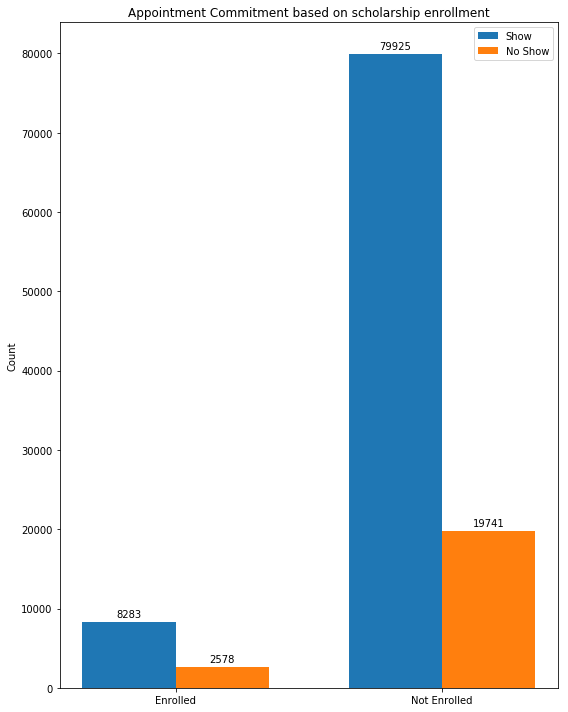

```python
# visualizing with a grouped bar chart

labels = ['Enrolled', 'Not Enrolled']
show = [len(enrolled_no), len(notenrolled_no)]
no_show = [len(enrolled_yes), len(notenrolled_yes)]

x = np.arange(len(labels))  # the label locations
width = 0.35  # the width of the bars

fig, ax = plt.subplots(figsize=(8,10))
rects1 = ax.bar(x - width/2, show, width, label='Show')
rects2 = ax.bar(x + width/2, no_show, width, label='No Show')

#setting labels,titles and legend.
ax.set_ylabel('Count')
ax.set_title('Appointment Commitment based on scholarship enrollment')
ax.set_xticks(x)
ax.set_xticklabels(labels)
ax.legend()

#this is for attaching text above each bar displaying the representative count
def labeling(rects):
    for rect in rects:
        height = rect.get_height()
        ax.annotate('{}'.format(height),xy=(rect.get_x() + rect.get_width() / 2, height),
                    xytext=(0, 3),  # 3 points vertical offset
                    textcoords="offset points",
                    ha='center', va='bottom')


labeling(rects1)
labeling(rects2)

fig.tight_layout()

plt.show()

#grouping chart reference: https://matplotlib.org/3.1.0/gallery/lines_bars_and_markers/barchart.html
```

> to further ivestigate and get a clear and fair idea of the above chart, it is only wiser to compare the percentage of patients who failed to show up upon each group. e.g, of all patients enrolled in a scholarship, how many did not show up?  
> **reminder: 'yes' indicates failure of showing up, 'no' indicates patient show up.**

```python
#Percentage of Patients enrolled in scholarship who failed to show up
# enrolled-noshow = enrolled-noshow/all enrolled patients
perc_enrolled = (len(enrolled_yes)/(len(enrolled_no)+len(enrolled_yes)))*100
perc_enrolled
```

```
23.73630420771568
```

```python
#Percentage of Patients not enrolled in a scholarship and failed to show up
# notenrolled-noshow = notenrolled-noshow/all not enrolled patients
perc_noenrolled = (len(notenrolled_yes)/(len(notenrolled_no)+len(notenrolled_yes)))*100
perc_noenrolled
```

```
19.807155900708366
```

```
 [Text(0.155393,1.08897,'not enrolled'), Text(-0.155393,-1.08897,'enrolled')],
 [Text(0.0847601,0.593983,'45.5%'), Text(-0.08476,-0.593983,'54.5%')])
```

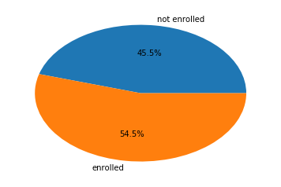

```python
#visualizing using pie chart
labels = ['not enrolled','enrolled']
sizes = [perc_noenrolled,perc_enrolled ]
plt.pie(sizes, labels = labels, autopct='%1.1f%%' )
```

### What age group of patients more likely to not show up?

The following investigation prunes unnecessary columns and divides the age groups into the following manner:

0-2 Infants  
3-12 Children  
13-18 Adolescence  
19-35 Young Adult  
36-59 Middle Aged  
60+ Senior

```python
#this question investigates which age group is more likely to not show? this implies the removal of unnecessary columns
df_agetype =  df.drop([ 'patientid', 'appointmentid', 'gender', 'scheduledday',
       'appointmentday', 'neighbourhood', 'scholarship', 'hipertension',
       'diabetes', 'alcoholism', 'handcap', 'sms_received'],  axis = 1)
df_agetype
```

|  | age | no_show |
| --- | --- | --- |
| 0 | 62 | No |
| 1 | 56 | No |
| 2 | 62 | No |
| 3 | 8 | No |
| 4 | 56 | No |
| 5 | 76 | No |
| 6 | 23 | Yes |
| 7 | 39 | Yes |
| 8 | 21 | No |
| 9 | 19 | No |
| 10 | 30 | No |
| 11 | 29 | Yes |
| 12 | 22 | No |
| 13 | 28 | No |
| 14 | 54 | No |
| 15 | 15 | No |
| 16 | 50 | No |
| 17 | 40 | Yes |
| 18 | 30 | No |
| 19 | 46 | No |
| 20 | 30 | Yes |
| 21 | 4 | Yes |
| 22 | 13 | Yes |
| 23 | 46 | No |
| 24 | 65 | No |
| 25 | 46 | No |
| 26 | 45 | No |
| 27 | 4 | No |
| 28 | 51 | No |
| 29 | 32 | No |
| ... | ... | ... |
| 110497 | 76 | No |
| 110498 | 59 | No |
| 110499 | 66 | No |
| 110500 | 59 | No |
| 110501 | 44 | No |
| 110502 | 22 | No |
| 110503 | 64 | No |
| 110504 | 4 | No |
| 110505 | 55 | No |
| 110506 | 5 | No |
| 110507 | 0 | No |
| 110508 | 59 | No |
| 110509 | 33 | No |
| 110510 | 64 | No |
| 110511 | 14 | No |
| 110512 | 41 | No |
| 110513 | 2 | No |
| 110514 | 58 | No |
| 110515 | 33 | Yes |
| 110516 | 37 | Yes |
| 110517 | 19 | No |
| 110518 | 50 | No |
| 110519 | 22 | No |
| 110520 | 42 | No |
| 110521 | 53 | No |
| 110522 | 56 | No |
| 110523 | 51 | No |
| 110524 | 21 | No |
| 110525 | 38 | No |
| 110526 | 54 | No |

110527 rows × 2 columns

```python
#split ages into seperate group age
# Bin edges that will be used to "cut" the data into groups

bin_edges = [-1 ,2,12 , 18, 35,59, 120 ]
agelabels = ['Infants','Children' , 'Adolescence', 'Young Adult', 'Middle Aged', 'Senior']
# Creates age group column
df_agetype['age_group'] = pd.cut(df_agetype['age'], bin_edges, labels=agelabels)

# Checks for successful creation of this column
df_agetype.head()
```

|  | age | no_show | age_group |
| --- | --- | --- | --- |
| 0 | 62 | No | Senior |
| 1 | 56 | No | Middle Aged |
| 2 | 62 | No | Senior |
| 3 | 8 | No | Children |
| 4 | 56 | No | Middle Aged |

```python
# we're only interested in the patients who did not show up
df_agetype = df_agetype.query('no_show == "Yes"')
df_agetype.describe()
```

|  | age |
| --- | --- |
| count | 22319.000000 |
| mean | 34.317667 |
| std | 21.965941 |
| min | 0.000000 |
| 25% | 16.000000 |
| 50% | 33.000000 |
| 75% | 51.000000 |
| max | 115.000000 |

```
Text(0.5,0,'age group')
```

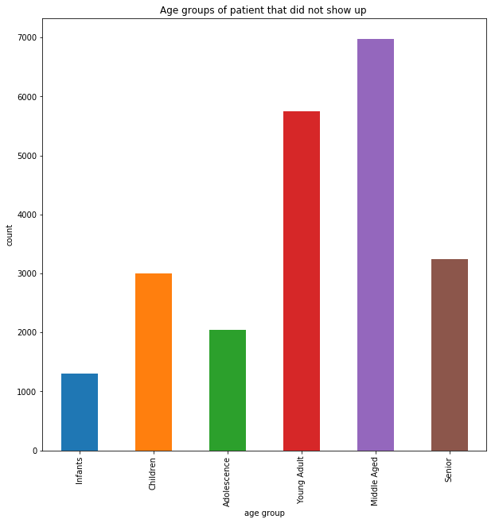

```python
#exploring the numbers of each group
vis = df_agetype.groupby(['age_group'])['no_show'].count().plot.bar( figsize=(10,10))
vis.set_title('Age groups of patient that did not show up ')
vis.set_ylabel('count')
vis.set_xlabel('age group')
```

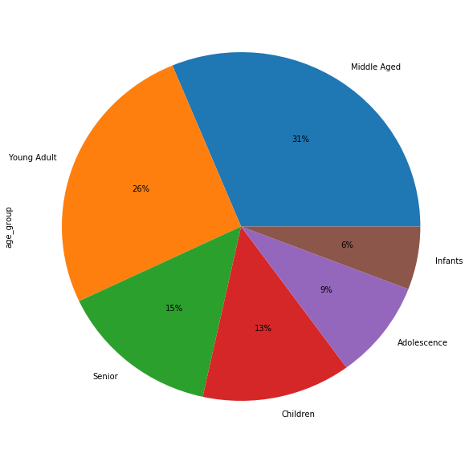

```python
df_agetype['age_group'].value_counts().plot.pie(autopct='%1.0f%%', figsize=(10,10))
```

# What is the common medical issue of patients not likely to show up?

### This section investigates which medical issue is most common in patients who fail to show up, the following is examined:

> - hipertension
> - diabetes
> - alcholism
> - handcap
> - no issues

```python
# This question implies pruning unnecessary columns
df_issues = df

df_issues.drop(columns=['patientid', 'appointmentid', 'gender', 'scheduledday',
       'appointmentday', 'age', 'neighbourhood', 'scholarship', 'sms_received'] , inplace = True)
```

```python
df.columns
```

```
Index(['hipertension', 'diabetes', 'alcoholism', 'handcap', 'no_show'], dtype='object')
```

```python
#we're only interested in the patients who failed to show up
df_issues = df_issues.query('no_show == "Yes"')

hypertension = df_issues.query('hipertension == 1')
diabetes = df_issues.query('diabetes == 1')
alcoholism = df_issues.query('alcoholism == 1')
handcap = df_issues.query('handcap == 1')
noissues = df_issues.query('hipertension == 0 and diabetes ==0 and alcoholism==0 and handcap == 0')
```

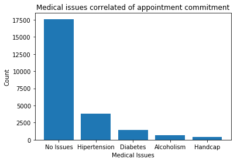

```python
# visualizing with a bar chart
locations = [1, 2 , 3 , 4 , 5 ]

heights = [len(noissues),len(hypertension),  len(diabetes),len(alcoholism), len(handcap) ]
labels = ['No Issues', 'Hipertension', 'Diabetes', 'Alcoholism', 'Handcap']
plt.bar(locations, heights, tick_label=labels)
plt.title('Medical issues correlated of appointment commitment')
plt.xlabel('Medical Issues')
plt.ylabel('Count');
```

```
 [Text(-0.745071,0.80924,'No Issues'),
  Text(0.442025,-1.00728,'Hipertension'),
  Text(0.979143,-0.501277,'Diabetes'),
  Text(1.07892,-0.214307,'Alcoholism'),
  Text(1.09842,-0.0588479,'Handcap')],
 [Text(-0.406403,0.441403,'73.7%'),
  Text(0.241105,-0.549426,'15.8%'),
  Text(0.534078,-0.273424,'6.0%'),
  Text(0.588503,-0.116895,'2.8%'),
  Text(0.599141,-0.0320989,'1.7%')])
```

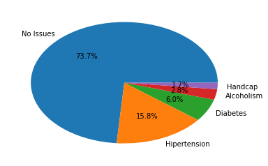

```python
#visualizing using pie chart

plt.pie(heights, labels = labels, autopct='%1.1f%%' )
```

## Conclusions

> **What age group of patients more likely to not show up?**  
> This investigation started by first segmenting the data based on the ages of patients and placing them in groups in the following manner:
> - Infants
> - Children
> - Adolescence
> - Young Adult
> - Middle Aged
> - Senior

> The investigation concludes the following: Middle aged patients represents the most group of patients that fail to show up to appointments compromising a total of 31%. Moreover, second comes the young adults group with 26% and a following of 15% and 13% of seniors and children age groups, respectively.

> **What is the most common medical issue of patients not likely to show up?**  
> This question investigates the common medical issue found in patients who fail to show up, the findings show that a majority of 73.7% patients suffer from none of the issues mentioned. However, the most common medical issue found in 15.8% of patients who stood up on their appointment have hipertension. The remaining medical issues represent merely an insignificant percentage, only 6% have diabetes, 2.8% suffer from alcholosim and 1.7% with handicap issues. Thus, we may conclude that medical issues is not sufficiant to detect the absence of patients from their appointments.

## Submitting your Project

> Before you submit your project, you need to create a .html or .pdf version of this notebook in the workspace here. To do that, run the code cell below. If it worked correctly, you should get a return code of 0, and you should see the generated .html file in the workspace directory (click on the orange Jupyter icon in the upper left).

> Alternatively, you can download this report as .html via the **File** > **Download as** submenu, and then manually upload it into the workspace directory by clicking on the orange Jupyter icon in the upper left, then using the Upload button.

> Once you've done this, you can submit your project by clicking on the "Submit Project" button in the lower right here. This will create and submit a zip file with this .ipynb doc and the .html or .pdf version you created. Congratulations!

```python
from subprocess import call
call(['python', '-m', 'nbconvert', 'Investigate_a_Dataset.ipynb'])
```

```
0
```